# ps_5.Rmd

Hamaad Mehal

3/10/2020

# ML 1)

Not all respondents were asked every question. 2652 respondents were asked the question about whether the USA should create a gun registry.

# ML 2)

Of the respondents that got asked all four gun policy questions, 23.69 percent are gun owners. (For the purposes of this question, you can assume that the people who answered “not sure” are not gun owners). Round to 2 digits after the decimal point.

# ML 3)

The average “agreement” score (from 1-4) on the statement_gun_rights variable is 2.05 for those respondents who live in households without guns, while the average “agreement” score in households with guns is 2.6.

# ML 4)

Another set of questions asks about religion. The first ranked category of religion for the age group of people 18-30 is “Nothing in particular”. The first-ranked religion category for people 30 and older is “Catholic”.

# ML 5)

Lots of people say that the younger generation has the highest percent of “nones;” people who answer “nothing in particular”, when you ask them their religion. In the 18-30 age group, “nothing in particular” is ranked 1, while in the 30 and above group, “nothing in particular” is ranked 4.

# ML 6)

Consider again the nones (all people who responded “nothing in particular”) when asked about their religion. In this group, the most popular position is to ‘Strongly Agree’ (strongly disagree, disagree, agree, or strongly agree?) that it is more important for the government to control who owns guns than it is for the government to protect the right to own guns.

# Question 2A

# Question 2B

# Question 2C

# Question 2D

Drawing Two Cards

Card Colors

| Draw | First card red? | Second card red? | Color Outcome |
| --- | --- | --- | --- |
| Diamonds, Clubs | TRUE | FALSE | mixed |
| Hearts, Diamonds | TRUE | TRUE | both red |
| Diamonds, Clubs | TRUE | FALSE | mixed |
| Clubs, Clubs | FALSE | FALSE | both black |
| Diamonds, Clubs | TRUE | FALSE | mixed |
| Hearts, Clubs | TRUE | FALSE | mixed |
| Clubs, Clubs | FALSE | FALSE | both black |
| Diamonds, Diamonds | TRUE | TRUE | both red |
| Hearts, Clubs | TRUE | FALSE | mixed |
| Hearts, Diamonds | TRUE | TRUE | both red |

# Question 2E

48.6 percent of cards have “mixed” colors.

# Question 3

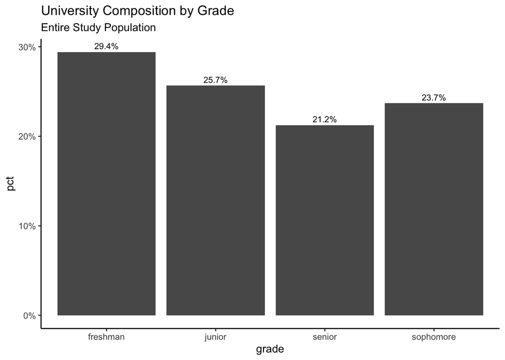

# Question 4

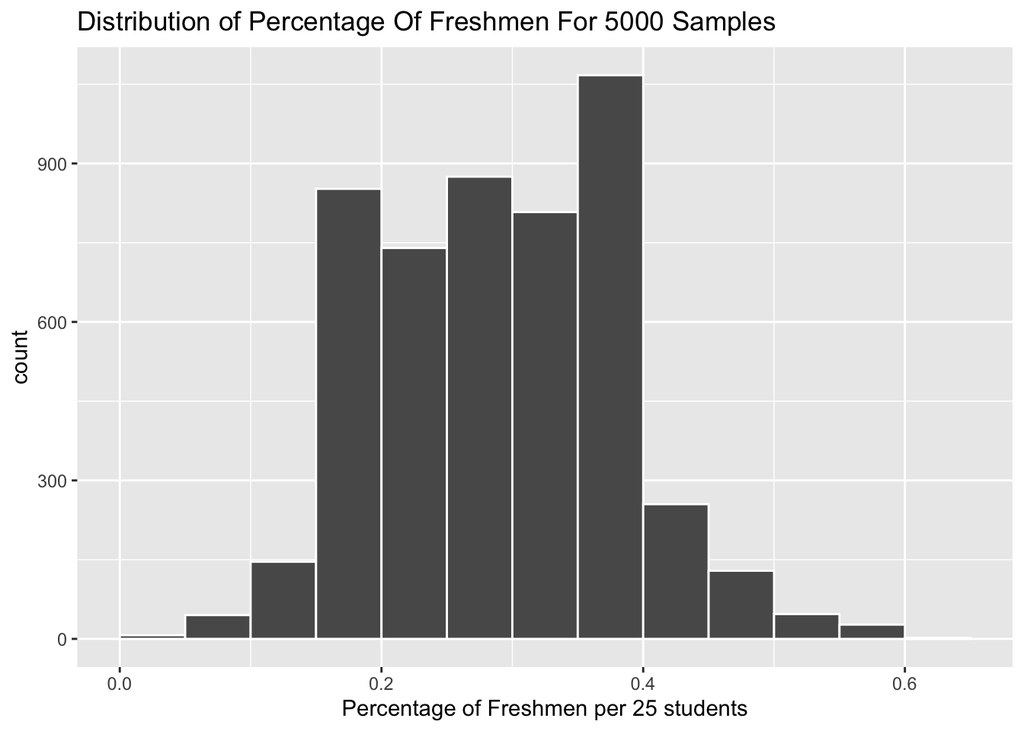

# Question 5

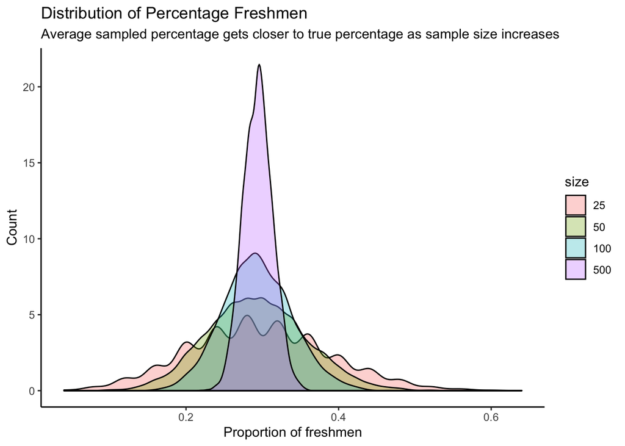

# Question 6

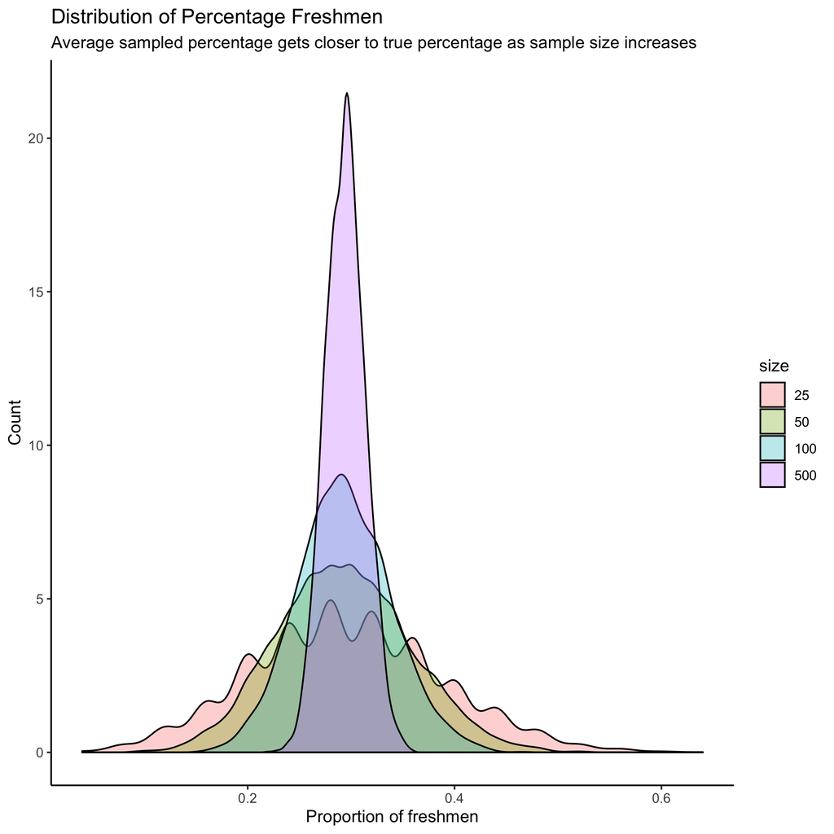

https://rpubs.com/hamaadwmehal/ps_5_graph

# Question 7

https://github.com/GOV-1005-Spring-2020/problem-set-5-hamaadwmehal/issues/1

# Question 8

I would prefer to sample 1000 people in each of the five major cities. This is my preference because, in a large, diverse country, we need to account for the diversity of the country which is generally more evident in urban areas than in states (as states have demographic inequities). Thus, I decided the most accurate estimate of the *population* and the *population parameter* would be derived from *sampling* an urban population, especially as the samples from the urban areas are also larger. Obviously, we cannot perform a *census* on the entire population as that is too expensive, exhaustive, and there’s not enough time. I believe the best *point estimates* that we will be able to label as being a *representative sample* will be from the urban samples as they are larger and will likely account for the diversity of the country better. Also, because the election is based on the popular vote, a larger sample from an urban, diverse population will allow the campaign to best understand where it stands in the polls. Because of this, I believe urban polling provides the most *generalizability*, and although *biased sampling* will occur as urban polling overrepresents diversity and urban-specific demographics, urban polling also provides the most *random sampling* in understanding the diversity in a country with elections based on a popular vote election.

Collaborators: Tahmid Ahmed, Ibraheem Khan, Hamid Khan, Naina Tejani, Jun Yong Kim, Asmer Safi